[figure not shown]

[figure not shown]

# Model fit

### Assumption checks

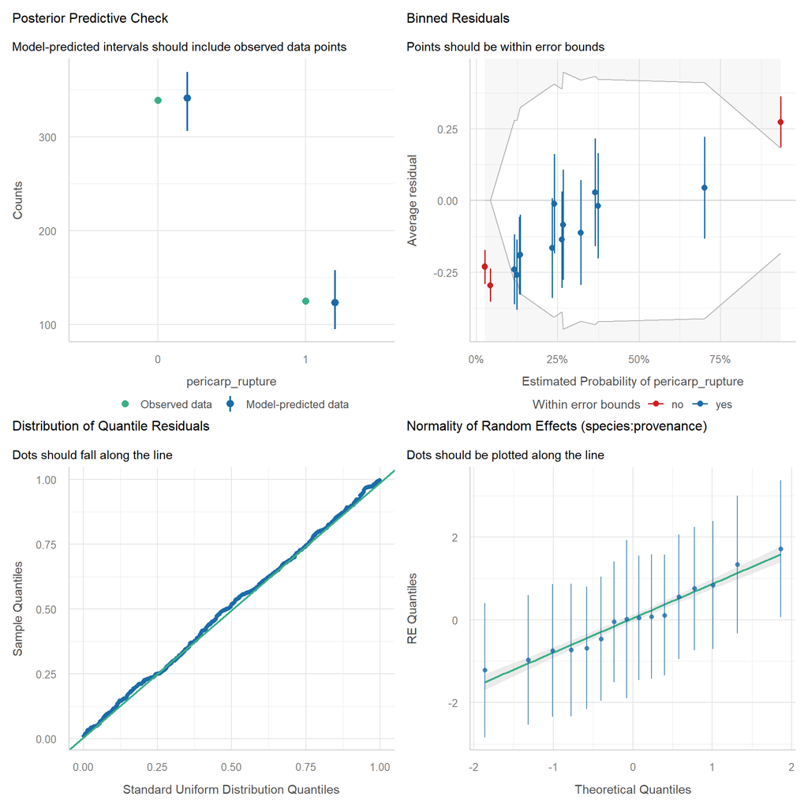

### Indices of model fit

| Metric | Value |
| --- | --- |
| AIC | 436.5 |
| AICc | 436.9 |
| BIC | 473.7 |
| R2 (cond.) | 0.46 |
| R2 (marg.) | 0.30 |
| ICC | 0.22 |
| RMSE | 0.37 |
| Sigma | 1 |
| Log_loss | 0.41 |
| Score_log | -53.64 |
| Score_spherical | 0.02 |

For interpretation of performance metrics, please refer to [this documentation](https://easystats.github.io/performance/reference/model_performance.html).

# Parameter estimates

### Plot

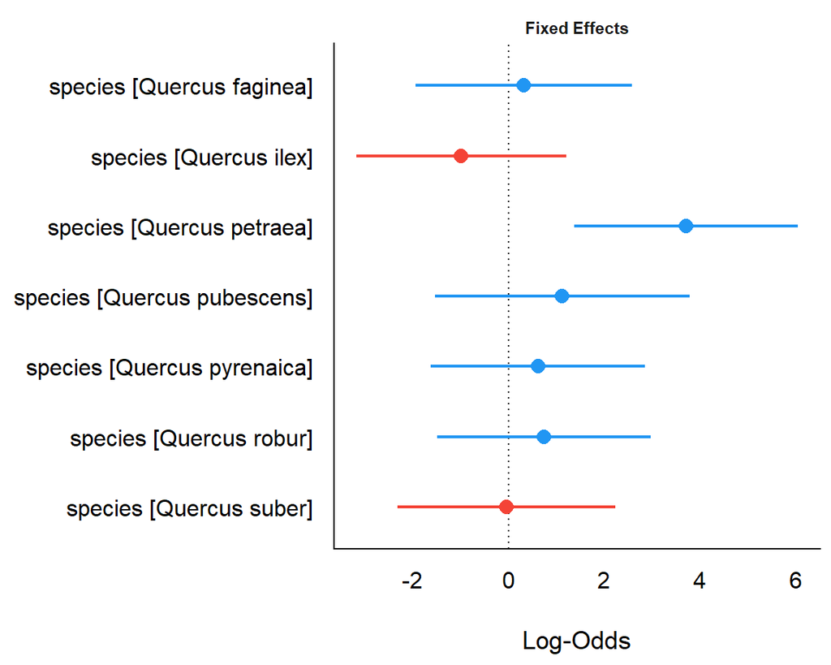

### Tabular summary

# Fixed Effects

| Parameter | Log-Odds | SE | 95% CI | z | p |
| --- | --- | --- | --- | --- | --- |
| (Intercept) | -1.89 | 0.85 | (-3.56, -0.22) | -2.22 | 0.026 |
| species [Quercus faginea] | 0.32 | 1.15 | (-1.94, 2.58) | 0.28 | 0.780 |
| species [Quercus ilex] | -0.99 | 1.12 | (-3.18, 1.21) | -0.88 | 0.379 |
| species [Quercus petraea] | 3.71 | 1.19 | (1.37, 6.05) | 3.11 | 0.002 |
| species [Quercus pubescens] | 1.12 | 1.36 | (-1.54, 3.78) | 0.83 | 0.409 |
| species [Quercus pyrenaica] | 0.62 | 1.14 | (-1.62, 2.85) | 0.54 | 0.589 |
| species [Quercus robur] | 0.75 | 1.14 | (-1.49, 2.98) | 0.65 | 0.513 |
| species [Quercus suber] | -0.04 | 1.16 | (-2.32, 2.23) | -0.04 | 0.971 |

# Random Effects

| Parameter | Coefficient | 95% CI |
| --- | --- | --- |
| SD (Intercept: species:provenance) | 0.97 | (0.55, 1.73) |

To find out more about table summary options, please refer to [this documentation](https://easystats.github.io/parameters/reference/model_parameters.html).

# Predicted Values

### Plot

[output not shown]

# Text reports

### Textual summary

We fitted a logistic mixed model (estimated using ML and nlminb optimizer) to predict pericarp_rupture with species (formula: pericarp_rupture ~ species). The model included species as random effects (formula: ~1 | species:provenance). The model’s total explanatory power is substantial (conditional R2 = 0.46) and the part related to the fixed effects alone (marginal R2) is of 0.30. The model’s intercept, corresponding to species = Quercus coccifera, is at -1.89 (95% CI (-3.56, -0.22), p = 0.026). Within this model:

- The effect of species (Quercus faginea) is statistically non-significant and positive (beta = 0.32, 95% CI (-1.94, 2.58), p = 0.780)
- The effect of species (Quercus ilex) is statistically non-significant and negative (beta = -0.99, 95% CI (-3.18, 1.21), p = 0.379)
- The effect of species (Quercus petraea) is statistically significant and positive (beta = 3.71, 95% CI (1.37, 6.05), p = 0.002)
- The effect of species (Quercus pubescens) is statistically non-significant and positive (beta = 1.12, 95% CI (-1.54, 3.78), p = 0.409)
- The effect of species (Quercus pyrenaica) is statistically non-significant and positive (beta = 0.62, 95% CI (-1.62, 2.85), p = 0.589)
- The effect of species (Quercus robur) is statistically non-significant and positive (beta = 0.75, 95% CI (-1.49, 2.98), p = 0.513)
- The effect of species (Quercus suber) is statistically non-significant and negative (beta = -0.04, 95% CI (-2.32, 2.23), p = 0.971)

Standardized parameters were obtained by fitting the model on a standardized version of the dataset. 95% Confidence Intervals (CIs) and p-values were computed using a Wald z-distribution approximation. The model’s total explanatory power is substantial (conditional R2 = 0.46) and the part related to the fixed effects alone (marginal R2) is of 0.30

### Model information

|  | name | value |
| --- | --- | --- |
| 1 | is_binomial | TRUE |
| 2 | is_bernoulli | TRUE |
| 3 | is_count | FALSE |
| 4 | is_poisson | FALSE |
| 5 | is_negbin | FALSE |
| 6 | is_beta | FALSE |
| 7 | is_betabinomial | FALSE |
| 8 | is_orderedbeta | FALSE |
| 9 | is_dirichlet | FALSE |
| 10 | is_exponential | FALSE |

[output cut: 143 more lines]

````r
---
title: "Regression model summary from `{easystats}`"
output:
  flexdashboard::flex_dashboard:
    theme:
      version: 4
      # bg: "#101010"
      # fg: "#FDF7F7"
      primary: "#0054AD"
      base_font:
        google: Prompt
      code_font:
        google: JetBrains Mono
params:
  model: model
  check_model_args: check_model_args
  parameters_args: parameters_args
  performance_args: performance_args
---

```{r setup, include=FALSE}
library(flexdashboard)
library(easystats)

# Since not all regression model are supported across all packages, make the
# dashboard chunks more fault-tolerant. E.g. a model might be supported in
# `{parameters}`, but not in `{report}`.
#
# For this reason, `error = TRUE`
knitr::opts_chunk$set(
  error = TRUE,
  out.width = "100%"
)

# helper function for printing `{report}` outputs
bracket_to_parantheses <- function(text) {
  gsub("]", ")", gsub("[", "(", text, fixed = TRUE), fixed = TRUE)
}
```

```{r easydashboard-1}
# Get user-specified model data
model <- params$model

# Is it supported by `{easystats}`? Skip evaluation of the following chunks if not.
is_supported <- insight::is_model_supported(model)

if (!is_supported) {
  unsupported_message <- sprintf(
    "Unfortunately, objects of class `%s` are not yet supported in {easystats}.\n
    For a list of supported models, see `insight::supported_models()`.",
    class(model)[1]
  )
}
```


Model fit
=====================================

Column {data-width=700}
-----------------------------------------------------------------------

### Assumption checks

```{r check-model, eval=is_supported, fig.height=10, fig.width=10}
check_model_args <- c(list(model), params$check_model_args)
# add verbose, if not done yet
if (is.null(check_model_args$verbose)) check_model_args$verbose <- FALSE
tryCatch(
  {
    do.call(performance::check_model, check_model_args)
  },
  error = function(e) {
    cat(insight::format_message(
      "\nSomething did not work as expected. Please file an issue at {.url https://github.com/easystats/easystats/issues/} and post the following output:",
      paste0("\n`", e$message, "`")
    ))
  }
)
```

```{r easydashboard-2, eval=!is_supported}
cat(unsupported_message)
```

Column {data-width=300}
-----------------------------------------------------------------------

### Indices of model fit

```{r easydashboard-3, eval=is_supported}
# {performance}
performance_args <- c(list(model), params$performance_args)
# add verbose, if not done yet
if (is.null(performance_args$verbose)) performance_args$verbose <- FALSE
table_performance <- do.call(performance::performance, performance_args)
print_md(table_performance, layout = "vertical", caption = NULL)
```


```{r easydashboard-4, eval=!is_supported}
cat(unsupported_message)
```

For interpretation of performance metrics, please refer to <a href="https://easystats.github.io/performance/reference/model_performance.html" target="_blank">this documentation</a>.

Parameter estimates
=====================================

Column {data-width=550}
-----------------------------------------------------------------------

### Plot

```{r dot-whisker, eval=is_supported}
# `{parameters}`
parameters_args <- c(list(model), params$parameters_args)
# add verbose, if not done yet
if (is.null(parameters_args$verbose)) parameters_args$verbose <- FALSE
table_parameters <- do.call(parameters::parameters, parameters_args)

plot(table_parameters)
```


```{r easydashboard-5, eval=!is_supported}
cat(unsupported_message)
```

Column {data-width=450}
-----------------------------------------------------------------------

### Tabular summary

```{r easydashboard-6, eval=is_supported}
print_md(table_parameters, caption = NULL)
```


```{r easydashboard-7, eval=!is_supported}
cat(unsupported_message)
```

To find out more about table summary options, please refer to <a href="https://easystats.github.io/parameters/reference/model_parameters.html" target="_blank">this documentation</a>.


Predicted Values
=====================================

Column {data-width=600}
-----------------------------------------------------------------------

### Plot

```{r expected-values, eval=is_supported, fig.height=10, fig.width=10}
# {modelbased}
int_terms <- find_interactions(model, component = "conditional", flatten = TRUE)
con_terms <- find_variables(model)$conditional

if (is.null(int_terms)) {
  model_terms <- con_terms
} else {
  model_terms <- clean_names(int_terms)
  int_terms <- unique(unlist(strsplit(clean_names(int_terms), ":", fixed = TRUE)))
  model_terms <- c(model_terms, setdiff(con_terms, int_terms))
}

text_modelbased <- tryCatch(
  {
    lapply(unique(model_terms), function(i) {
      estimate_means(model, by = i, verbose = FALSE)
    })
  },
  error = function(e) {
    cat(insight::format_message(
      "\nSomething did not work as expected. Please file an issue at {.url https://github.com/easystats/easystats/issues/} and post the following output:",
      paste0("\n`", e$message, "`")
    ))
    NULL
  }
)

if (!is.null(text_modelbased)) {
  ggplot2::theme_set(theme_modern())
  # all_plots <- lapply(text_modelbased, function(i) {
  #   out <- do.call(visualisation_recipe, c(list(i), modelbased_args))
  #   plot(out) + ggplot2::ggtitle("")
  # })
  all_plots <- lapply(text_modelbased, function(i) {
    out <- visualisation_recipe(i, join_dots = FALSE, show_data = FALSE)
    plot(out) + ggplot2::ggtitle("")
  })

  see::plots(all_plots, n_columns = round(sqrt(length(text_modelbased))))
}
```


```{r easydashboard-8, eval=!is_supported}
cat(unsupported_message)
```

Column {data-width=400}
-----------------------------------------------------------------------

### Tabular summary

```{r easydashboard-9, eval=is_supported, results="asis"}
if (!is.null(text_modelbased)) {
  for (i in text_modelbased) {
    tmp <- print_md(i)
    tmp[length(tmp)] <- paste(insight::compact_character(strsplit(tmp[length(tmp)], "\n")[[1]]), collapse = "; ")
    print(tmp)
  }
}
```


```{r easydashboard-10, eval=!is_supported}
cat(unsupported_message)
```


Text reports
=====================================

Column {data-width=500}
-----------------------------------------------------------------------

### Textual summary

```{r easydashboard-11, eval=is_supported, results='asis', collapse=TRUE}
# {report}
text_report <- tryCatch(
  {
    report(model, verbose = FALSE)
  },
  error = function(e) {
    cat(insight::format_message(
      "\nSomething did not work as expected. Please file an issue at {.url https://github.com/easystats/easystats/issues/} and post the following output:",
      paste0("\n`", e$message, "`")
    ))
    NULL
  }
)


text_report_performance <- tryCatch(
  {
    report_performance(model, verbose = FALSE)
  },
  error = function(e) {
    cat(insight::format_message(
      "\nSomething did not work as expected. Please file an issue at {.url https://github.com/easystats/easystats/issues/} and post the following output:",
      paste0("\n`", e$message, "`")
    ))
    NULL
  }
)

if (!is.null(text_report)) {
  cat(bracket_to_parantheses(text_report))
  cat("\n")
}

if (!is.null(text_report_performance)) {
  cat(bracket_to_parantheses(text_report_performance))
}
```


```{r easydashboard-12, eval=!is_supported}
cat(unsupported_message)
```

Column {data-width=500}
-----------------------------------------------------------------------

### Model information

```{r easydashboard-13, eval=is_supported}
model_info_data <- insight::model_info(model, verbose = FALSE)
model_info_data <- datawizard::data_to_long(as.data.frame(insight::compact_list(model_info_data)))

DT::datatable(model_info_data)
```

```{r easydashboard-14, eval=!is_supported}
cat(unsupported_message)
```
````